# Atividade 01 – Relatórios Técnicos em R Markdown

Trabalhando com o conjunto de dados iris e com equações em LaTeX.

Lucas Henrique Nogueira

2024-04-12

# Introdução

## A biblioteca iris

$~~$O dataframe “iris” é um conjunto de dados clássico na linguagem R que contém informações sobre características das flores da íris. Esse conjunto de dados é frequentemente utilizado em análises estatísticas, visualização de dados e aprendizado de máquina para demonstrar técnicas de exploração e modelagem de dados.

Diante disso, o objetivo proposto será a abordagem de operações básicas nessa biblioteca tais como:

```
- O cálculo da média, do menor e do maior valor da largura da pétala
- O plot de um gráfico e uma tabelas com os resultados obtidos
- A apresentação dos comandos utilizados para criação do gráfico
```

## Representação de equações matemáticas com o LaTex

$~~$O LaTeX é um sistema de preparação de documentos amplamente utilizado para criar documentos de alta qualidade, especialmente no contexto acadêmico e científico. Ele oferece um ambiente poderoso e flexível para produzir documentos bem formatados, como artigos, relatórios, teses, livros, apresentações entre outros.

Diante disso, o objetivo proposto será a representação das seguintes equações em LaTex:

```
- Fórmula de Bhaskara
- Propriedades de Somatório
- Limites Notáveis
- Média Amostral
```

# Conjunto de dados iris

## Operações com o conjunto de dados sobre a largura da pétala

$\rightarrow$ Pétala:

- Média da largura: 1.199
- Menor valor da largura: 0.100
- Maior valor da largura: 2.500

$\rightarrow$ Por espécie:

- Setosa:
  - Média da largura: 0.246
  - Menor valor da largura: 0.100
  - Maior valor da largura: 0.600
- Versicolor:
  - Média da largura: 1.326
  - Menor valor da largura: 1.000
  - Maior valor da largura: 1.800
- Virginica:
  - Média da largura: 2.026
  - Menor valor da largura: 1.400
  - Maior valor da largura: 2.500

## Plot do gráfico e da tabela das soluções

Largura de pétala e por espécie

| Tipo | Média | Menor | Maior |
| --- | --- | --- | --- |
| Pétala | 1.199 | 0.1 | 2.5 |
| Setosa | 0.246 | 0.1 | 0.6 |
| Versicolor | 1.326 | 1.0 | 1.8 |
| Virginica | 2.026 | 1.4 | 2.5 |

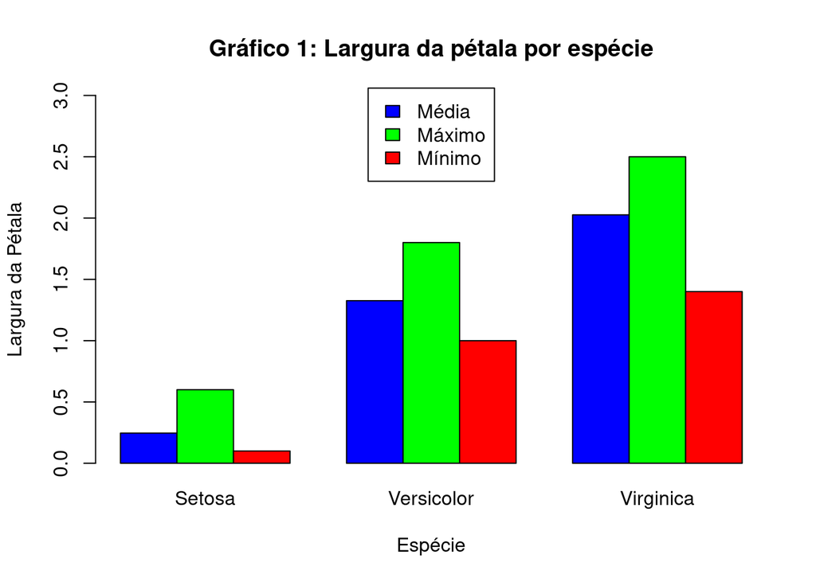

- Observações sobre os dados obtidos:

$~~$ A partir dos dados coletados pode-se observar que a espécie Virginica apresenta maiores valores de largura de pétala em relação as demais espécies. A espécie Setosa foi a que apresentou os menores valores em questão. Fato pode ser percebido visualmente pelo Gráfico 1 ou numericamente pela Tabela 1.

## Comandos utilizados para o plot do gráfico

```r
# Calculando a  média, o máximo e  o mínimo da largura da pétala
# por espécie e colocando em pétala

petala <- aggregate(Petal.Width ~ Species, data = iris, FUN = function(x)
              c(mean = mean(x), max = max(x), min = min(x)))


# Criando gráfico de barras com valores da média, do máximo
# e do mínimo da largura da pétala por espécie

barplot_height <- t(petala[, -1])  # Ajustando a alturas das barras
especies  <- c("Setosa", "Versicolor", "Virginica")



# Definindo ascores para média, máximo e mínimo

bar_colors <- c("blue", "green", "red")


# Criando o gráfico
barplot(barplot_height,
        beside = TRUE,
        col = bar_colors,
        ylim = c(0, max(barplot_height) * 1.2), # Definindo limite no eixo y
        names.arg = especies,

        # Configurando a legenda no centro do grafico
        legend.text = c("Média", "Máximo", "Mínimo"),
        args.legend = list(x = "top", bty = "n+1", inset = c(0, -0.02)),

        main = "Gráfico 1: Largura da pétala por espécie",
        ylab = "Largura da Pétala",
        xlab = "Espécie")
```

# Representação de equações com LaTex

## Equações Matemáticas

### Fórmula de Bhaskara:

$~~$Para o valor de $\Delta$, temos:

$$\begin{equation}
\Delta = b^2 - 4.a.c
\end{equation}$$

$~~$Para os valores de x, temos:

$$\begin{equation}
x = \frac{-b \pm \sqrt{\Delta}}{2.a}
\end{equation}$$

### Propriedade de somatório:

$$\sum_{i=1}^{n} \lambda x_i = \lambda
\sum_{i=1}^{n} x_i$$

### Limites notáveis:

$$\lim_{n \to \infty} \left(1 +
\frac{1}{n}\right)^n = e$$

$$\lim_{x \to 0} \frac{\sin x}{x} = 1$$

$$\lim_{x \to \infty} \frac{\log_a x}{x}
= 0 \quad \forall\: a > 1, \, a \in \mathbb{R}$$

### Média amostral:

$$\bar{x} = \frac{1}{n} \sum_{i=1}^{n}
x_i$$

# Considerações finais

O trabalho proposto teve como primeira etapa abordar operações básicas de um DataFrame caracteristíco da linguagem R (iris), como a média, o maior valor e o menor valor. Além da representação dos resultados através de uma tabela e de um gŕafico, foi possível também interpretar os resultados obtidos pelas operações. Em uma última etapa foi levantado também a utilização do LaTex a fim de representar algumas equações matemáticas importantes.

# Links

- Documentação do DataFrame iris:  
  $~~$ http://www.lac.inpe.br/~rafael.santos/Docs/CAP394/WholeStory-Iris.html
- Documentação do LaTex:  
  $~~$ https://www.learnlatex.org/en/